# The Package ForestElementsR

Peter Biber and Astor Toraño Caicoya

```r
library(ForestElementsR) # Attach ForestElementsR

# Other packages required in the code examples below
library(dplyr)
library(ggplot2)
library(purrr)
```

## 1 Introduction

Many methods from the fields of forest growth and yield, as well as forest inventory, that belong to the core contents of forest related education were not widely available in a contemporary form so far. To cover this deficit and to continue doing so in the long run is the driving idea behind the creation and development of the package *ForestElementsR*. The concept of the package is mainly based on experiences and procedures made and developed at the former Chair of Forest Growth and Yield at the Technical University of Munich. Therefore, the method and object collection covered by the current version of *ForestElementsR* is slightly biased towards German and Bavarian conditions. This is, however, not intended to be a limitation for the package’s future development. For this reason - too much pre-definition leads to restriction - *ForestElementsR* does not provide readily defined workflows. It does, in contrast, offer a collection of elementary (hence the name of the package) building blocks that can be combined into any workflow required by users for their specific requirements. If you are a developer, feel encouraged to use the methods and objects provided by *ForestElementsR* in your own forest-related R packages, e.g. for evaluating specific types of forest inventories, research plots, or the output of forest growth models. This is exactly what we, the authors of *ForestElementsR*, are currently using the package for.

Most of the functionality we provide with the package is focused on producing information that is typically connected to the fields of forest growth and yield, forest mensuration, and forest inventory. Therefore, there is a certain bias towards goal variables which are related to the production of wood in one way or the other. However, even data from classic forest surveys can be evaluated in many ways that allow conclusions about forest structure and diversity. A few such methods are implemented in the current version of *ForestElementsR*, and we intend to add more in the future. We deem this important, because such approaches make a better use of forest data with regard to multifunctional forest management and planning.

It is an important design requirement of *ForestElementsR* not to be just a conglomerate of functions and objects that exist independently of each other. We hope users will see overarching concepts when they find similarities in the naming of our functions and objects, and the composition of function calls. Other, even more important bundling features are the package’s open Species Coding System and the hierarchically organized family of objects that represent (samples from) forest stands.

With *ForestElementsR* we would like to address a broad audience. **Practitioners** might want to apply it for many purposes from using single functions in a “forest pocket calculator” style to evaluate forest stand surveys by arranging functions in a workchain way. **Scientists** will hopefully find the package useful for carrying out routine evaluations of forest data (like volume estimates, site indexing) that are regular prerequisites for in-depth scientific analyses. **Students** could profit from applying *ForestElementR*’s functionality to the extensive set of example data that comes with the package. We are confident that this would help them to develop an understanding and intuition about quantitative key methods in forestry as well as about the quantities themselves.

We should add that, besides our own developments, we also have quite shamelessly implemented methods developed and published by other authors that have proven themselves useful in our daily work. We have tried our best to find and cite the original publications correctly in order to give credit to whom it belongs.

Before we proceed, let us put out an **Important Warning**: While the functions and objects we provide with *ForestElementsR* behave exactly as described in the documentation, professional training in the fields of forestry, forest management, forest science is required to apply them correctly and to understand what their output actually means. If you are a hobby forester, you are more than welcome to make use of this package, but be sure to consult a professional before you draw important conclusions from what you get out of your evaluations. We also would like to point out another trivial wisdom that, however, seems to be ignored on a regular basis: *If your data are bad, don’t expect to get good results.*

In the following sections we give an overview of the most important features of *ForestElementsR*. We do not delve deeply into all details as these can be taken from the specific documentations provided for each function. For two major features, namely the species coding system, and the representation of yield tables, we provide their own vignettes.

## 2 Object Families

*ForestElementsR* comprises three main families of [S3](https://adv-r.hadley.nz/s3.html) objects that are intended to facilitate the users’ as well as the developers’ lives. These relate to the representations of forest plots and stands, the species coding system, and *ForestElementR*’s yield table implementation.

### 2.1 Representations of Plots and Stands

The basic and most versatile class for representing plots or stands is `fe_stand`. For how to make such an object from data call the documentation `?fe_stand`. As each tree in an fe_stand object can have its own representation number (i.e. an information about how many trees it represents per ha), it can represent (a cutout from) a forest stand as well as any kind of sample with varying representation like, e.g., angle count samples (where the representation number of a tree depends on its dbh) or n-tree samples (where typically, the outermost tree is only half represented). Also a concentric circle based design can be represented; however, we provide specialized objects for these. Let’s have a closer look at such an object:

```r
# spruce_beech_1_fe_stand is one of the included example objects,
# for an overview, type "?example_data"
spruce_beech_1_fe_stand
```

```
#> $stand_id
#> [1] "spruce_beech_1"
#>
#> $area_ha
#> [1] 0.49
#>
#> $trees
#> # A tibble: 225 × 12
#>    tree_id species_id    layer_key time_yr age_yr dbh_cm height_m
#>    <chr>   <tm_wwk_shrt>     <dbl>   <dbl>  <dbl>  <dbl>    <dbl>
#>  1 1       1                     1    2022     75   26.3     27.5
#>  2 2       1                     1    2022     75   34.8     30.9
#>  3 3       1                     1    2022     75   34.1     32.1
#>  4 4       1                     1    2022     75   33.6     32.7
#>  5 5       1                     1    2022     75   27.5     29.7
#>  6 6       1                     1    2022     75   30       30
#>  7 7       1                     1    2022     75   32.8     31.2
#>  8 8       1                     1    2022     75   34.8     30.9
#>  9 9       1                     1    2022     75   33.6     29.9
#> 10 10      1                     1    2022     75   38.5     31.5
#> # ℹ 215 more rows
#> # ℹ 5 more variables: crown_base_height_m <dbl>, crown_radius_m <dbl>,
#> #   removal <lgl>, ingrowth <lgl>, n_rep_ha <dbl>
#>
#> $small_trees
#> Dataframe mit 0 Spalten und 0 Zeilen
#>
#> attr(,"class")
#> [1] "fe_stand"
```

An fe_stand object is evidently a list-like object; its most important element is the data frame (tibble) “trees”, which contains all trees that were measured individually and have a dbh. Note that the element *small_trees* is still experimental and not yet used by any function we provide with *ForestElementsR*. It is intended to, in the future, provide a technical home for trees so small that they do not have a dbh (i.e. trees with heights < 1.3 m) or are under the size threshold for being measured individually, but are counted in size classes. Due to the multitude existing approaches, we haven’t decided on a representation in fe_stand objects, yet. The only current requirement for the small_trees element is that it has to be a data frame. In our example above, this data frame is empty. We have written fe_stand versions for the S3 generic functions *summary* and *plot*:

```r
oo <- options(fe_spec_lang = "eng")  # display species names in English

spruce_beech_1_fe_stand |> summary() # Give a summary of stand-level values
```

```
#> # A tibble: 2 × 9
#> # Groups:   time_yr [1]
#>   time_yr species_id     stem_number_ha basal_area_m2_ha d_q_cm d_dom_cm h_q_m
#>     <dbl> <tm_wwk_shrt>           <dbl>            <dbl>  <dbl>    <dbl> <dbl>
#> 1    2022 Norway spruce            306.            25.9    32.8     38.3  30.8
#> 2    2022 European beech           153.             9.85   28.6     36.0  28.1
#> # ℹ 2 more variables: h_dom_m <dbl>, v_m3_ha <dbl>
```

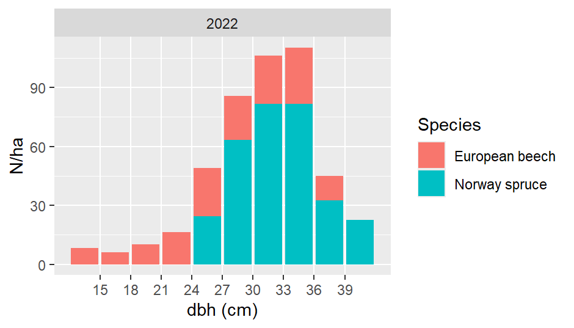

```r
spruce_beech_1_fe_stand |> plot()    # Make an appropriate plot
```

```r
options(oo)                          # Reset species name display option
```

If spatial information about the location of the stand (sample) and/or the single trees is available, the class `fe_stand_spatial` can be used. It is a child of fe_stand. All spatial functionality is taken from the package sf, therefore, fe_stand_spatial accepts a broad range of coordinate definitions, from simple cartesian coordinates to more or less all common geocoordinate definitions. The output of `summary` and `plot` for such an object is virtually the same as for its parent class `fe_stand`:

```r
oo <- options(fe_spec_lang = "sci")       # display scientific species names

# Example: A mixed mountain forest plot in the Bavarian Alps;
# for an overview, type "?example_data"
mm_forest_1_fe_stand_spatial |> summary() # Give a summary of stand-level values
```

```
#> Cast loses information. Goal code(s) 8 correspond to 2 original code(s).
#> # A tibble: 22 × 9
#> # Groups:   time_yr [5]
#>    time_yr species_id          stem_number_ha basal_area_m2_ha d_q_cm d_dom_cm
#>      <int> <tm_wwk_lng>                 <dbl>            <dbl>  <dbl>    <dbl>
#>  1    1975 Picea abies                  143.             21.4    43.6     60.3
#>  2    1975 Abies alba                   101.              6.16   27.8     42.5
#>  3    1975 Fagus sylvatica              161.              3.83   17.4     29.5
#>  4    1975 Acer pseudoplatanus          101.              3.55   21.1     27.2
#>  5    1984 Picea abies                   71.6            14.1    50.2     64.0
#>  6    1984 Abies alba                    53.7             3.47   28.7     46.6
#>  7    1984 Fagus sylvatica               89.5             3.22   21.4     36.7
#>  8    1984 Acer pseudoplatanus           59.7             2.54   23.3     31.4
#>  9    1995 Picea abies                   71.6            15.8    52.9     67.6
#> 10    1995 Abies alba                    41.8             3.87   34.4     50.2
#> # ℹ 12 more rows
#> # ℹ 3 more variables: h_q_m <dbl>, h_dom_m <dbl>, v_m3_ha <dbl>
```

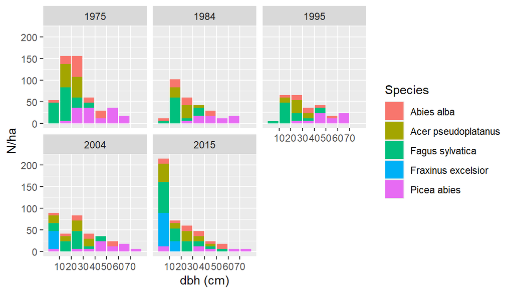

```r
mm_forest_1_fe_stand_spatial |> plot()    # Make an appropriate plot
```

```r
options(oo)                               # Reset species name display option
```

However, the spatial information about the outline of the stand (plot) and the positions of the trees can also be accessed graphically. In our example, the object represents a rectangular research plot where the coordinates are not geolocated:

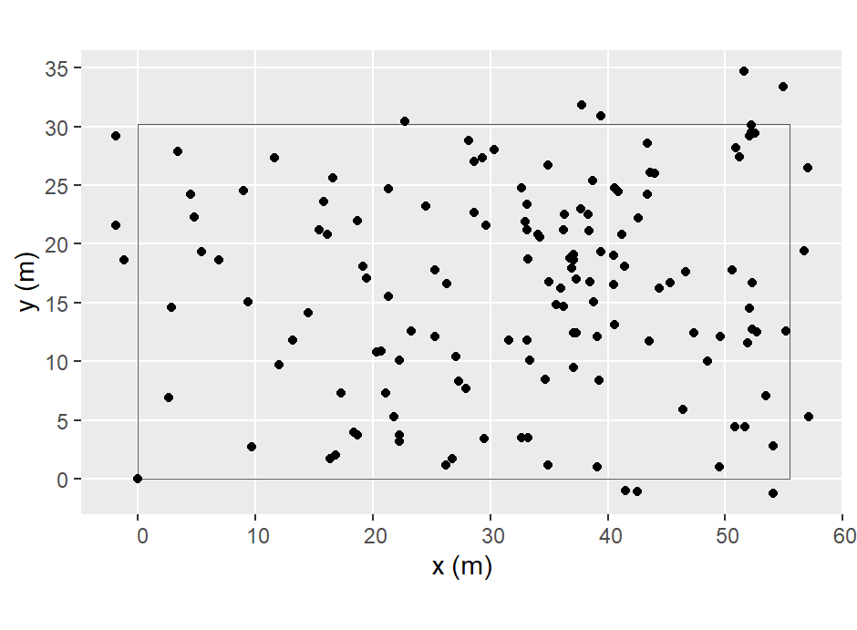

```r
mm_forest_1_fe_stand_spatial$outline |>
  ggplot() +
  geom_sf(fill = NA) +
  geom_sf(data = mm_forest_1_fe_stand_spatial$tree_positions) +
  xlab("x (m)") + ylab("y (m)")
```

An important special child of `fe_stand_spatial` is the `fe_ccircle_spatial` object. It is a generic container for sample plots with a concentric circle design. A multitude of such objects can be used for representing entire sample forest inventories. The latter is actually the intended use of `fe_ccircle_spatial` which can be done e.g. in R packages that build up on *ForestElementsR*. The `summary` and `plot` functions are also available for these objects:

```r
oo <- options(fe_spec_lang = "ger") # display German species names

spruce_pine_ccircle_spatial |> summary()
```

```
#> # A tibble: 2 × 9
#> # Groups:   time_yr [1]
#>   time_yr species_id   stem_number_ha basal_area_m2_ha d_q_cm d_dom_cm h_q_m
#>     <dbl> <tm_wwk_lng>          <dbl>            <dbl>  <dbl>    <dbl> <dbl>
#> 1    2020 Fichte                 207.             13.8   29.1     31.4  23.8
#> 2    2020 Kiefer                 642.             32.0   25.2     43.8  33.3
#> # ℹ 2 more variables: h_dom_m <dbl>, v_m3_ha <dbl>
```

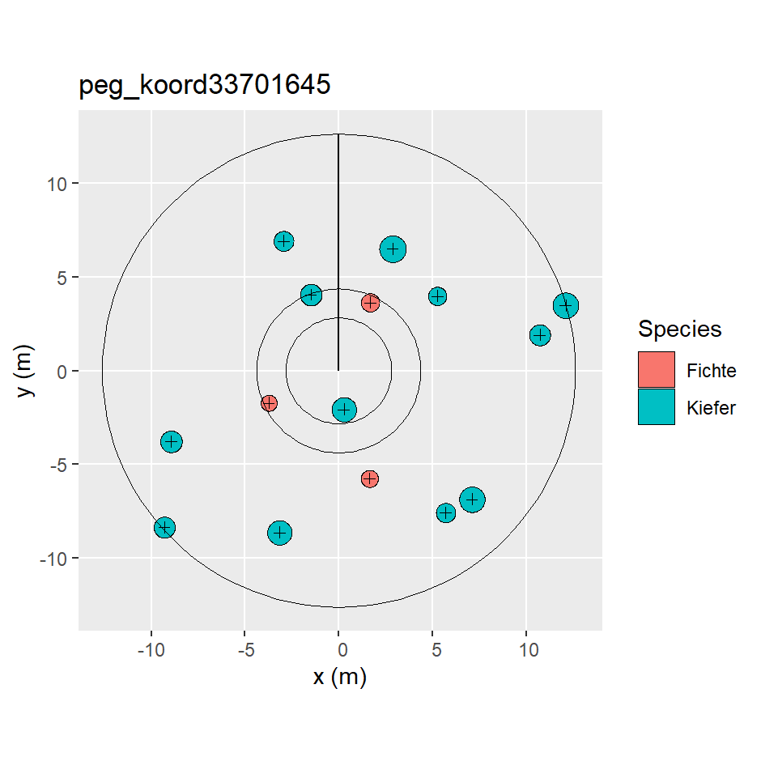

```r
spruce_pine_ccircle_spatial |> plot(dbh_scale = 3) # oversize dbh x3
```

```r
options(oo)        # Reset species name display option
```

We provide user-friendly functions for generating all the objects described above. These functions have the same name as the class of the object to be created. E.g. with `fe_stand()` you can generate an object of class `fe_stand` from your own data. This will only be successful if the candidate object passes a validation that makes sure it is not ill-defined. For details, check the documentations of the functions `fe_stand()`, `fe_stand_spatial()`, `fe_ccircle_spatial()`, and `fe_ccircle_spatial_notrees()` (a class designed for special cases e.g, permanent forest inventory samples where one plot does not have any trees at a given inventory period).

### 2.2 Species Coding System

Unfortunately, the different forest research institutions in Central Europe are typically using different tree species codings, which are typically not or only partly compatible with each other. This creates considerable friction e.g. in cross sectional analyses of data that come from different institutions. Therefore, *ForestElementsR* comes with a generic open species coding system that allows to cast between different codings. As we provide its own vignette, which covers this species coding system in detail, we give only an outline here.

The system is designed in a way that coding casts work as long as there is no logical problem in the specific situation to solve, even when the two codings of interest are not entirely compatible. That means, e.g., when incompatibilities between two codings exist for very uncommon species or species groups only, they will not hamper the majority of casts. When a species coding cast loses information, a message will be issued, but the cast will be executed. This is the case when a species cast leads from an individually coded species in the original coding into a species group code in the goal coding. Currently, six species codings are implemented in *ForestElementsR*. Five of them are codings that are in use in practice, probably most prominently the coding of the German National Forest Inventory (Riedel et al. 2017). All specific codings are linked to an internal master coding, which guarantees consistency. While the authors have a faint hope that this master coding could eventually become a common standard, they are also realists and understand the longevity of traditions.

Many functions in *ForestElementsR* that utilize species codings, e.g. the volume function `v_gri()`, will try to convert any given species coding into the most similar supported one for which parameters are available. In this way, useful functions that were originally developed at one institution and are therefore compatible with a specific species coding, become more widely applicable without forcing users to do tedious technical pull-ups beforehand. When examining the code examples in the previous section, you may have noticed that R’s `options()` mechanism is used there to select the language which is used to display species names. Let us demonstrate this here again:

```r
# Define a vector of species ids compatible with the coding used by the
# Bavarian Forest Service
species_ids <- as_fe_species_bavrn_state(c(10, 20, 21, 24, 68, 62, 60))
# How they are displayed depends on the current setting of the option
# fe_spec_lang
species_ids
```

```
#> <fe_species_bavrn_state[7]>
#> [1] 10 20 21 24 68 62 60
```

```r
# Check the option
options("fe_spec_lang") # if NULL or "code" the number codes are displayed
```

[output not shown]

```r
# Set to English (and keep the prevous option settings in oo)
oo <- options(fe_spec_lang = "eng")
species_ids
```

```
#> <fe_species_bavrn_state[7]>
#> [1] Norway spruce      Scots pine         eastern white pine Arolla pine
#> [5] sweet cherry       small-leaved lime  European beech
```

```r
# Set to scientific names
options(fe_spec_lang = "sci")
species_ids
```

```
#> <fe_species_bavrn_state[7]>
#> [1] Picea abies      Pinus sylvestris Pinus strobus    Pinus cembra
#> [5] Prunus avium     Tilia cordata    Fagus sylvatica
```

```r
# Set to German
options(fe_spec_lang = "ger")
species_ids
```

```
#> <fe_species_bavrn_state[7]>
#> [1] Fichte       Kiefer       Strobe       Zirbe        Vogelkirsche
#> [6] Winterlinde  Buche
```

```r
# Set to codes
options(fe_spec_lang = "code")
species_ids
```

```
#> <fe_species_bavrn_state[7]>
#> [1] 10 20 21 24 68 62 60
```

```r
# Reset to the previous setting before enforcing English
options(oo)
```

See the vignette Tree Species Codings in ForestElementsR for an in-detail description of the species coding system of *ForestElementsR*

### 2.3 Yield Tables

Yield tables might be the most important tools forest science has ever provided to forest practice. They represent an invaluable wealth of empirical data that has been condensed into tabular descriptions of forest stand growth that are easy to work with. For about three decades, however, they have been increasingly frowned upon for several reasons, including their limited applicability to mixed species stands, their inherent restriction to even aged stands only, and their representation of forest growth under environmental conditions that have since changed, and cannot be considered as stable as they were when the data behind the tables were collected. Nevertheless, when handled wisely, yield tables can still be highly valuable assets in our tool kit. Therefore, we developed a generic implementation of yield tables in *ForestElementsR* that is designed to work equally well with yield tables of different origin with different specifications and descriptive variables. An initial collection of yield tables for important tree species in Central Europe has already been implemented and comes readily with *ForestElementsR*; this collection will certainly keep growing. Currently, it covers the yield tables contained in BayMinELF (1990). All readily available tables are listed in the *ForestElementsR*’s documentation. You can look them up with `?yield_tables`. It is also possible and intended that users can make their own preferred yield tables usable with *ForestElementsR* even though they are not part of the collection that comes with the package. The key object here is `fe_yield_table`, and the function `fe_yield_table()` was designed for generating such objects in a user friendly way. See the vignette Yield Tables in ForestElementsR for a detailed description of the yield table system of *ForestElementR*.

The yield table system allows for an easy visualization of yield tables. We demonstrate that by example of the widely known yield table for Norway spruce by Wiedemann (1942). Applying `plot()` to an object of class `fe_yield_table` displays the ‘site index fan’, i.e. the mean stand height over age curves for the site indexes (si) covered by the table.

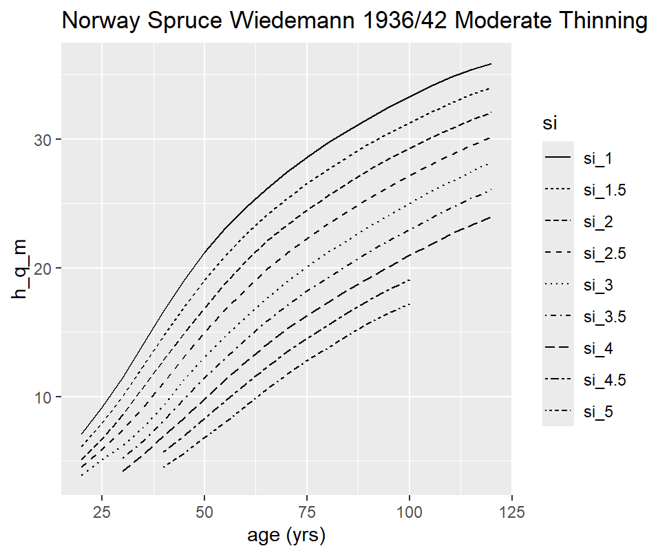

```r
fe_ytable_spruce_wiedemann_moderate_1936_42 |> plot()
```

However, the visualization is not limited to the site index fan of a yield table. Actually, any variable that is covered by a given yield table can be visualized. Below, see how to obtain the names of all these variables:

```r
# Get all variables available in the yield table of interest
vars <- names(fe_ytable_spruce_wiedemann_moderate_1936_42$values)
vars
```

```
#>  [1] "h_q_m_si_plus_025"        "n_ha"
#>  [3] "ba_m2_ha"                 "d_q_cm"
#>  [5] "v_m3_ha"                  "pai_m3_ha_yr"
#>  [7] "pai_perc_yr"              "mai_m3_ha_yr"
#>  [9] "red_v_m3_ha"              "red_pai_m3_ha_yr"
#> [11] "red_mai_m3_ha_yr"         "red_pre_yield_m3_ha_10yr"
#> [13] "h_q_m"                    "tvp_m3_ha"
```

The following code plots the age-curves of the standing volume (variable name `v_m3_ha`); while the resulting figure is not embedded in this vignette due to memory constraints, the reader is encouraged to run this example.

```r
# select standing volume ...
fe_ytable_spruce_wiedemann_moderate_1936_42 |> plot(variable = "v_m3_ha")
```

With the code example below, we plot the periodic annual increment (variable name `pai_m3_ha_yr`).

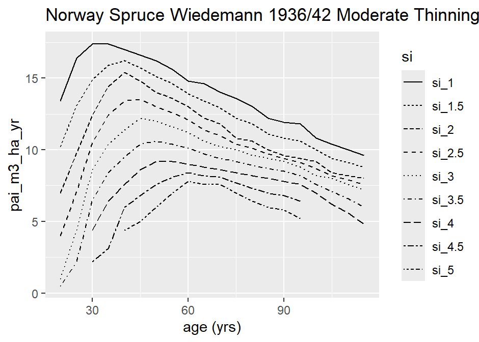

```r
# ... and the periodic annual incement for plotting
fe_ytable_spruce_wiedemann_moderate_1936_42 |> plot(variable = "pai_m3_ha_yr")
```

Historical fact: As the diagram above clearly shows, Wiedemann’s yield tables were not constructed by fitting functions to electronic data, but in a rather visual and manual way to point clouds on millimeter paper. At the time, viable alternatives were not available. Nevertheless, *ForestElementsR* keeps yield table values as provided (as long as they are consistent) and does not attempt to smooth or harmonize them. We deem that important to ensure consistency with previous applications of widespread yield tables. For more information about the yield table system of *ForestElementsR* see the vignette Yield Tables in ForestElementsR.

## 3 Low Level Methods

The functions we call *low level methods* are arguably the most important constituents of *ForestElementsR*. These functions do not directly work on objects of the *fe_stand* family, but they are typically the elementary ingredients of such. The purpose of these low level methods is to be as generic as possible. This makes them the main tools for users who want to use *ForestElementsR* in a “forestry pocket calculator” style. As their input, they typically expect vectors of tree variables. Their output typically is a single value that is an aggregate of the input version or a vector that corresponds to each element of the input vector(s). Randomly chosen examples for such functions are `d_q` (quadratic mean diameter), `d_100` (dominant diameter), `h_q`, `h_100` (quadratic mean height, dominant height), and `site_index` (site index according to a yield table). If low level methods require species information, which is usually the case if they rely on species specific parameters, a vector of a supported species coding (i.e. an object from the *fe_species* family) has to be their first input variable. Examples for this are `v_gri` (merchantable wood volume), `shannon_index` (species diversity index after Shannon and Weaver (1948)), `h_standard_bv` (Bavarian standard height curve system after Kennel (1972)). We demonstrate a little workchain in “forestry pocket calculator” style:

Assuming we have sampled eight trees in a forest stand and recorded their diameters at breast height, dbh, in cm.

```r
dbh <- c(30.5, 30.9, 33.3, 35.1, 19.4, 19.5, 28.1, 25.5)
```

For making things a bit more complex, we also assume that these trees have been sampled with the angle count method and a factor of 4. This means that each tree represents a basal area of 4 m²/ha. Therefore, the *number of trees* that each tree represents per ha depends on its diameter at breast height:

```r
# Calculate each tree's basal area in m²
ba <- (dbh / 100)^2 * pi/4
# Angle count factor 4/ba gives each tree's individual representation number
# per ha
nrep_ha <- 4 / ba
nrep_ha
```

```
#> [1]  54.74827  53.34002  45.92843  41.33861 135.32145 133.93710  64.49967
#> [8]  78.32308
```

Given this information, we have functions for calculating classic stand diameters:

```r
# Quadratic mean diameter
dq <- d_q(dbh, nrep_ha)
dq
```

```
#> [1] 25.8988
```

```r
# Note that the quadratic mean diameter is always greater than the arithmetic
# mean as calculated here
stats::weighted.mean(dbh, w = nrep_ha)
```

```
#> [1] 25.26209
```

```r
# Assmann's dominant diameter (quadratic mean diameter of the 100 thickest stems
# per ha)
d_100(dbh, nrep_ha)
```

```
#> [1] 33.76636
```

```r
# Weise's dominant diameter (quadratic mean diameter of 20% thickest stems)
d_dom_weise(dbh, nrep_ha)
```

```
#> [1] 33.27737
```

As a next step we would like to calculate the trees’ wood volumes. However, since their heights were not measured, we used a few orienting height measurements of trees with diameters close to the quadratic mean diameter dq of 25.9 cm. From this measurements we estimated the corresponding height, hq, to be 23.6 m. Let’s further assume that all trees in our sample are European beech (*Fagus sylvatica*) trees from a 72-year-old monospecific stand. This information allows us to estimate heights for all trees with the standard height curve system used by the Bavarian State Forest Service (Kennel 1972):

```r
# Make a vector of 8 species ids = 5 and transform it into a tum_wwk_short
# species coding vector (see vignette about Species Codings in ForestElementsR),
# where code 5 stands for European beech.
# For our monospecific sample, we could make things even simpler (i.e. providing
# only one species id value for all trees together to the functions for height
# and volume estimates below), but we prefer to show the more generic approach
# here, where each tree has its own corresponding species id.
species_id <- rep(5, 8) |> as_fe_species_tum_wwk_short()
species_id
```

```
#> <fe_species_tum_wwk_short[8]>
#> [1] 5 5 5 5 5 5 5 5
```

```r
oo <- options(fe_spec_lang = "eng") # display species names in English
species_id
```

```
#> <fe_species_tum_wwk_short[8]>
#> [1] European beech European beech European beech European beech European beech
#> [6] European beech European beech European beech
```

```r
hq  <- 23.6 # Height value corresponding to the quadratic mean diameter dq
age <- 72   # Stand age

# Estimate a height for each tree in the stand based on the information above
# with the Bavarian standard height curve system
h <- h_standard_bv(species_id, dbh, age, dq, hq)
h    # Vector of height estimates corresponding to the dbh vector
```

```
#> [1] 24.64269 24.72119 25.15889 25.45388 21.49704 21.53731 24.13349 23.49549
```

```r
options(oo) # Switch back options to previous values
```

Having now dbh and height values for all trees, we can calculate their volumes. To that end, *ForestElementsR* provides the function `v_gri()` that estimates a trees’ standing merchantable wood volume over bark in m³:

```r
v <- v_gri(species_id, dbh, h)
v
```

```
#> [1] 0.9195415 0.9479353 1.1274727 1.2724106 0.3071555 0.3111566 0.7583854
#> [8] 0.6016652
```

```r
v_ha <- sum(v * nrep_ha)
v_ha
```

```
#> [1] 384.569
```

For estimating the volume increment, we could use a yield table (being aware that yield tables substantially underestimate the actual growth observed in Central Europe over the last decades). For our stand we will use the yield table for European beech by Wiedemann (1931) as published in BayMinELF (2018). This table is available as an `fe_yield_table` object in *ForestElementsR* under the name `fe_ytable_beech_wiedemann_moderate_1931`. In the following code examples, we will not provide too many details about how to actually use yield tables in *ForestElementsR*. See the vignette Yield Tables in ForestElementsR for detailed explanations. The first thing we have to do is to find out the site index (ger. “Bonität”) of our stand according to the selected yield table. For this, we require the stand’s quadratic mean height, hq = 23.6 m, and the stand’s age, which is 72 years:

```r
si <- site_index(
  age    = age,
  size   = hq,
  ytable = fe_ytable_beech_wiedemann_moderate_1931,
  si_variable = "h_q_m"
)

si
```

```
#> [1] 1.518717
```

This site index of 1.5 refers to the traditional way of site indexing where 1.0 expresses the best site quality covered by a yield table. Typically, 4.0, 5.0, or 6.0, depending on the table, would indicate the weakest site conditions. In the vignette Yield Tables in ForestElementsR, we describe alternative supported ways of expressing site indexes. With the site index now known, the function `ytable_lookup()` can be used to obtain the stand’s current increment in m³/ha/yr according to the table.

```r
inc <- ytable_lookup(age = age, si = si, variable = "pai_m3_ha_yr",
                     ytable = fe_ytable_beech_wiedemann_moderate_1931)
inc
```

```
#> [1] 10.84781
```

This increment estimate, 10.8 m³/ha/yr, refers to a fully stocked stand. To find out whether it should be corrected due to the actual stand density, the stocking level (ger. “Bestockungsgrad”) of the stand of interest should be determined. We require the stand’s basal area, its age, and the site index for doing so. As we have assumed that our trees are an angle count sample with factor 4, each tree represents a basal area of 4 m²/ha. Therefore, the stand’s basal area amounts to 32 m²/ha. The stocking level results in:

```r
# Basal area per hectare from angle count sample
ba_ha <- length(dbh) * 4
ba_ha
```

```
#> [1] 32
```

```r
# Stocking level
stl <- stocking_level(ba = ba_ha, age = age, si = si,
                      ytable = fe_ytable_beech_wiedemann_moderate_1931)

stl
```

```
#> [1] 1.045007
```

With a stocking level of about 1, our stand is fully stocked compared to the yield table. While some yield tables come with their own increment correction tables for deviating stocking levels, we have decided not to implement these in *ForestElementsR* so far. Instead, we advocate for the simple, classic way of multiplying the original increment estimate by the stocking level if the latter is less than one. An easy generic way for applying this rule in R would be as follows:

```r
inc * min(1, stl) # correct the increment only if stocking level < 1
```

```
#> [1] 10.84781
```

A simple alternative way for estimating a stand increment in our example situation could be applying the height and diameter growth functions of the German National Forest Inventory (Riedel et al. 2017) to the quadratic mean diameter tree (ger. “Grundflächenmittelstamm”):

```r
# Current volume of the quadratic mean diameter tree (dbh = dq, height = hq)
species_id  <- as_fe_species_tum_wwk_short(5) # Beech in tum_wwk_short coding
vol_current <- v_gri(species_id, dq, hq)

# future (+5 years) dq and hq estimated with German NFI3 functions
dq_future   <- d_age_gnfi3(species_id, age + 5, dq, age)
hq_future   <- h_age_gnfi3(species_id, age + 5, hq, age)

# future volume of the quadratic mean diameter tree (dq-tree)
vol_future  <- v_gri(species_id, dq_future, hq_future)

# Estimated annual volume increment of the dq-tree
# Division by 5 years, because we want an annual value
iv_mean_tree <- (vol_future - vol_current) / 5

# The dq-tree currently represents so many trees per ha ...
n_ha <- sum(nrep_ha)

# ... therefore, we estimate the stand's increment as
iv_stand <- iv_mean_tree * n_ha

iv_stand
```

```
#> [1] 14.78204
```

It does not come as a surprise that the latter increment estimate is higher than the one obtained from the yield table. The growth functions from the German National Forest Inventory (NFI) were calibrated with data that reflect the recent reality of forest growth, in contrast with Wiedemann’s yield table which was developed using data that reflect the growth of over nine decades or more ago. See Pretzsch et al. (2014), and Pretzsch et al. (2023) for more information about forest growth trends in Central Europe. In general, increment estimates that are not directly derived from repeated measurements must *always* be interpreted with care and professional knowledge. Both methods used in the code examples above have their specific strengths and weaknesses. Do not use them if you are not aware of these.

We would like to draw your attention to another family of low level functions, which enable evaluations of forest structure and diversity. In this field, we see a huge potential for assessing ecosystem services beyond wood production and biodiversity based on standard forest mensuration data (see Biber et al. (2021), and Biber et al. (2020)). Let us have a look at the function `shannon_index()` that allows you to calculate the classic species diversity index after Shannon and Weaver (1948). In the simplest case, the function `shannon_index()` requires just a vector of tree species codes as an input. See the function’s documentation for more options. We apply it to example data that come with *ForestElementsR* (type `?example_data` for an overview), namely a monospecific stand, an even-aged mixed stand of two species, and a selection forest (ger. “Plenterwald”):

```r
# Monospecific stand
#   1. Extract the tree data frame frame from an fe_stand_object
trees <- norway_spruce_1_fe_stand$trees
#   2. Run shannon_index() on its species_id column (technically a vector)
shannon_index(trees$species_id)
```

```
#> [1] 0
```

```r
# Two-species mixed stand
trees <- spruce_beech_1_fe_stand$trees
shannon_index(trees$species_id)
```

```
#> [1] 0.6365142
```

```r
# Selection forest
trees <- selection_forest_1_fe_stand$trees
shannon_index(trees$species_id)
```

```
#> [1] 1.149218
```

Clearly, there is a plausible gradient with the monospecific stand having zero species diversity, the selection forest having the highest diversity, and the even-aged mixed stand being in between. The species profile index by Pretzsch (2009) uses the same basic concept, but adds a vertical component. Therefore, the species profile index is higher, the more vertically structured a stand is, and the more species it contains. In a mono-layered, monospecific stand, this index is zero. In *ForestElementsR*, it is implemented as the function `species_profile`, whose minimum input requirements are a vector of species codes, and a corresponding vector of tree heights. We apply it to the same example stands as above:

```r
 # Monospecific stand
trees <- norway_spruce_1_fe_stand$trees
species_profile(trees$species_id, trees$height_m)
```

```
#> [1] 0.06521436
```

```r
# Two-species mixed stand
trees <- spruce_beech_1_fe_stand$trees
species_profile(trees$species_id, trees$height_m)
```

```
#> [1] 0.8928083
```

```r
# Selection forest
trees <- selection_forest_1_fe_stand$trees
species_profile(trees$species_id, trees$height_m)
```

```
#> [1] 1.988993
```

Predictably, the gradient we obtain is similar to what we find for the shannon index above. However, the species profile index of the monospecific stand is somewhat greater than zero, indicating that the stand is at least, to some degree, vertically structured. The values we obtain for the other two forest stands are quite typical for the stand types they represent. A lot more could be said about indicators for stand structure and diversity, but this is beyond the scope of this vignette. Interested readers are referred to the publications we mentioned above. We see an increasing demand for such indicators in forest practice and science, and plan to extend the corresponding family of functions in *ForestElementsR* in the future.

## 4 High Level Methods

With the term *high level methods* we mean functions that expect objects of the `fe_stand` class or its children as one of their inputs. Internally and usually, these functions are tailored combinations of low level methods, offering users more aggregated workflows that integrate seamlessly with `fe_stand`and child objects. Still, we consider the currently existing suite of high level methods far from complete, but useful already. As a design requirement, all high level functions that operate on the single trees of a `fe_stand` (or child) object have in common the argument `tree_filter`. By default, this argument is `TRUE` which means that the function will use all trees stored in the `trees` data frame inside the `fe_stand` object (see Section 2.1). However, any valid R expression that evaluates to a logical value for each row of the `trees` data frame will work. This provides a high level of adaptability to varying data evaluation requirements. Let us demonstrate this using the function `stand_sums_static` and the example object `mm_forest_1_fe_stand_spatial` which is a cutout of a mixed mountain forest stand that has been surveyed several times since 1975. The function `stand_sums_static` provides an overview of the most important static stand sum and mean values (from mean diameters to the wood volume per ha) for each available survey of an `fe_stand` object:

```r
oo <- options(fe_spec_lang = "eng")

# Include all trees in evaluation with stand_sums_static
mm_forest_1_fe_stand_spatial |> stand_sums_static()
```

```
#> Cast loses information. Goal code(s) 8 correspond to 2 original code(s).
#> # A tibble: 22 × 9
#> # Groups:   time_yr [5]
#>    time_yr species_id     stem_number_ha basal_area_m2_ha d_q_cm d_dom_cm h_q_m
#>      <int> <tm_wwk_lng>            <dbl>            <dbl>  <dbl>    <dbl> <dbl>
#>  1    1975 Norway spruce           143.             21.4    43.6     60.3  31.2
#>  2    1975 silver fir              101.              6.16   27.8     42.5  23.9
#>  3    1975 European beech          161.              3.83   17.4     29.5  19.8
#>  4    1975 sycamore maple          101.              3.55   21.1     27.2  19.6
#>  5    1984 Norway spruce            71.6            14.1    50.2     64.0  34.3
#>  6    1984 silver fir               53.7             3.47   28.7     46.6  26.4
#>  7    1984 European beech           89.5             3.22   21.4     36.7  24.4
#>  8    1984 sycamore maple           59.7             2.54   23.3     31.4  22.8
#>  9    1995 Norway spruce            71.6            15.8    52.9     67.6  33.6
#> 10    1995 silver fir               41.8             3.87   34.4     50.2  26.7
#> # ℹ 12 more rows
#> # ℹ 2 more variables: h_dom_m <dbl>, v_m3_ha <dbl>
```

```r
# For applying a filter, we must refer to the column names of the "trees" data
# frame inside the fe_stand object. These are
mm_forest_1_fe_stand_spatial$trees |> names()
```

```
#>  [1] "tree_id"             "species_id"          "layer_key"
#>  [4] "time_yr"             "age_yr"              "dbh_cm"
#>  [7] "height_m"            "crown_base_height_m" "crown_radius_m"
#> [10] "removal"             "ingrowth"            "n_rep_ha"
```

```r
# Assume, we want to include only the trees that were not removed ...
mm_forest_1_fe_stand_spatial |> stand_sums_static(tree_filter = !removal)
```

```
#> Cast loses information. Goal code(s) 8 correspond to 2 original code(s).
#> # A tibble: 22 × 9
#> # Groups:   time_yr [5]
#>    time_yr species_id     stem_number_ha basal_area_m2_ha d_q_cm d_dom_cm h_q_m
#>      <int> <tm_wwk_lng>            <dbl>            <dbl>  <dbl>    <dbl> <dbl>
#>  1    1975 Norway spruce            71.6            12.6    47.3     60.9  31.8
#>  2    1975 silver fir               53.7             2.93   26.4     44.0  24.4
#>  3    1975 European beech           89.5             2.31   18.1     32.1  21.0
#>  4    1975 sycamore maple           59.7             2.22   21.8     28.5  20.0
#>  5    1984 Norway spruce            71.6            14.1    50.2     64.0  34.3
#>  6    1984 silver fir               41.8             3.29   31.7     47.5  27.2
#>  7    1984 European beech           89.5             3.22   21.4     36.7  24.4
#>  8    1984 sycamore maple           53.7             2.40   23.9     31.6  23.1
#>  9    1995 Norway spruce            71.6            15.8    52.9     67.6  33.6
#> 10    1995 silver fir               41.8             3.87   34.4     50.2  26.7
#> # ℹ 12 more rows
#> # ℹ 2 more variables: h_dom_m <dbl>, v_m3_ha <dbl>
```

```r
# ... and now only the removal trees
mm_forest_1_fe_stand_spatial |> stand_sums_static(tree_filter = removal)
```

```
#> # A tibble: 10 × 9
#> # Groups:   time_yr [4]
#>    time_yr species_id     stem_number_ha basal_area_m2_ha d_q_cm d_dom_cm h_q_m
#>      <int> <tm_wwk_lng>            <dbl>            <dbl>  <dbl>    <dbl> <dbl>
#>  1    1975 Norway spruce           71.6             8.86    39.7     58.4  30.5
#>  2    1975 silver fir              47.7             3.23    29.4     40.2  23.4
#>  3    1975 European beech          71.6             1.52    16.4     25.7  17.9
#>  4    1975 sycamore maple          41.8             1.33    20.2     24.9  19.0
#>  5    1984 silver fir              11.9             0.179   13.8     17.3  12.5
#>  6    1984 sycamore maple           5.97            0.132   16.8     16.8  18.5
#>  7    2004 Norway spruce           41.8            10.1     55.6     66.9  34.6
#>  8    2004 European beech          35.8             1.72    24.7     42.5  24.7
#>  9    2004 sycamore maple          11.9             0.440   21.7     24.2  19.7
#> 10    2015 Norway spruce            5.97            0.866   43       43    30.7
#> # ℹ 2 more variables: h_dom_m <dbl>, v_m3_ha <dbl>
```

```r
# Focus on Norway spruce and the surveys after 2000 only. Note, for filtering
# on species names you must use the format() function
# 1. Remaining trees only
mm_forest_1_fe_stand_spatial |>
  stand_sums_static(
    tree_filter =
      format(species_id, "eng") == "Norway spruce" & time_yr > 2000 & !removal
  )
```

```
#> # A tibble: 2 × 9
#> # Groups:   time_yr [2]
#>   time_yr species_id    stem_number_ha basal_area_m2_ha d_q_cm d_dom_cm h_q_m
#>     <int> <tm_wwk_lng>           <dbl>            <dbl>  <dbl>    <dbl> <dbl>
#> 1    2004 Norway spruce           35.8             6.28   47.3     70.1  34.0
#> 2    2015 Norway spruce           35.8             5.78   45.4     72.5  33.9
#> # ℹ 2 more variables: h_dom_m <dbl>, v_m3_ha <dbl>
```

```r
# 2. Removal trees only
mm_forest_1_fe_stand_spatial |>
  stand_sums_static(
    tree_filter =
      format(species_id, "eng") == "Norway spruce" & time_yr > 2000 & removal
  )
```

```
#> # A tibble: 2 × 9
#> # Groups:   time_yr [2]
#>   time_yr species_id    stem_number_ha basal_area_m2_ha d_q_cm d_dom_cm h_q_m
#>     <int> <tm_wwk_lng>           <dbl>            <dbl>  <dbl>    <dbl> <dbl>
#> 1    2004 Norway spruce          41.8            10.1     55.6     66.9  34.6
#> 2    2015 Norway spruce           5.97            0.866   43       43    30.7
#> # ℹ 2 more variables: h_dom_m <dbl>, v_m3_ha <dbl>
```

```r
options(oo)
```

When an `fe_stand` or child object comprises more than one survey, stand level periodic annual increments can be calculated. The high level function for this task is `stand_sums_dynamic`. Internally, it uses the high level function `stand_sums_static` we introduced above, and the low level function `stand_level_increment`. As all trees represented in an `fe_stand` object must have a dbh entry, the basal area increment will always be calculated. If enough information is available, i.e. each tree also has a height entry (be it measured or estimated), the volume increment will be calculated, too. The method of increment calculation follows the classic approach $iv = (vs_2 + vr_2 - vs_1)/p$, where $iv$ is the mean annual stand volume increment during a period of $p$ years between two subsequent surveys. With $vs_2$ and $vs_1$ we indicate the standing volume at the second and the first of two subsequent surveys, respectively. $vr_2$ is the volume that has been removed (or died) after the first survey up to, and including, the second survey #2. For the basal area increment, the approach is exactly the same as shown for the volume increment. We demonstrate `stand_sums_dynamic` by example of the mixed mountain forest stand introduced above:

```r
oo <- options(fe_spec_lang = "eng")

# Calculate basal area and volume increments for an fe_stand object that covers
# more than one survey
ssd <- stand_sums_dynamic(mm_forest_1_fe_stand_spatial)
```

```
#> Cast loses information. Goal code(s) 8 correspond to 2 original code(s).
```

```r
ssd |> print(n = Inf)
```

```
#> # A tibble: 22 × 4
#>    time_yr species_id     iba_m2_ha_yr iv_m3_ha_yr
#>      <int> <tm_wwk_lng>          <dbl>       <dbl>
#>  1    1975 Norway spruce       NA          NA
#>  2    1984 Norway spruce        0.176       3.94
#>  3    1995 Norway spruce        0.146       1.52
#>  4    2004 Norway spruce        0.0745      1.58
#>  5    2015 Norway spruce        0.0337      0.311
#>  6    1975 silver fir          NA          NA
#>  7    1984 silver fir           0.0598      1.10
#>  8    1995 silver fir           0.0532      0.574
#>  9    2004 silver fir           0.0825      1.49
#> 10    2015 silver fir           0.0981      1.59
#> 11    1975 European beech      NA          NA
#> 12    1984 European beech       0.101       1.72
#> 13    1995 European beech       0.107       1.33
#> 14    2004 European beech       0.0964      1.32
#> 15    2015 European beech       0.170       2.13
#> 16    1975 sycamore maple      NA          NA
#> 17    1984 sycamore maple       0.0354      0.794
#> 18    1995 sycamore maple       0.0289      0.0709
#> 19    2004 sycamore maple       0.0369      0.671
#> 20    2015 sycamore maple       0.0577      0.462
#> 21    2004 European ash        NA          NA
#> 22    2015 European ash         0.0399      0.175
```

```r
options(oo)
```

As in this example height values are available for all trees in all surveys, not only the basal area increment, but also the volume increment is calculated. The increment entry at the first survey is `NA`, because there is no preceding survey, and an increment entry always relates to the period between the survey of interest and the previous one. Species overarching increments can be easily calculated from the output of `stand_sums_dynamic` just by standard R methods, or even more conveniently with `group_by` and `summarise` as provided by the `dplyr` package:

```r
# Species-overarching increments
stand_sums_dynamic(mm_forest_1_fe_stand_spatial) |>
  group_by(time_yr) |>
  summarise(
    iba_m2_ha_yr = sum(iba_m2_ha_yr, na.rm = TRUE),
    iv_m3_ha_yr  = sum(iv_m3_ha_yr,  na.rm = TRUE)
  )
```

```
#> Cast loses information. Goal code(s) 8 correspond to 2 original code(s).
#> # A tibble: 5 × 3
#>   time_yr iba_m2_ha_yr iv_m3_ha_yr
#>     <int>        <dbl>       <dbl>
#> 1    1975        0            0
#> 2    1984        0.372        7.56
#> 3    1995        0.335        3.49
#> 4    2004        0.290        5.06
#> 5    2015        0.399        4.67
```

```r
# Zero increments for 1975 are obtained, because no previous survey is
# available, so no meaningful increment can be calculated there
```

```r
# fe_stand
get_area_ha(norway_spruce_1_fe_stand)
```

```
#> [1] 0.49
```

```r
# fe_stand_spatial
get_area_ha(mm_forest_1_fe_stand_spatial)
```

```
#> [1] 0.16761
```

```r
# fe_ccircle_spatial (the area of the outermost circle is returned)
get_area_ha(spruce_pine_ccircle_spatial)
```

```
#> [1] 0.05
```

So far, with this vignette we have provided an overview of the features of the package *ForestElementsR* we deem most important for standard users. Such a vignette, however, is not the place to describe each function in detail. You find this information in the specific documentation of the functions.

## 5 Expert Methods

What we call expert methods are functions that are typically useful for developers. They are not relevant for standard users who want to work with forest data. An important group of such functions are the constructors for the S3 classes (i.e. the object families) we implemented, e.g. `fe_stand`, `fe_yield_table`, etc. Following standard practice, the names of these constructors begin with “new_” followed by the name of the class, e.g. `new_fe_stand`, or `new_fe_yield_table`. Only persons who are well aware of what they are doing should use these constructors, as they do not prevent users from creating ill-formed objects. Checking objects for adherence to the classes’ requirements is the task of the validators, another important group of expert functions. Their names begin with “validate_” followed by the name of the class, e.g. `validate_fe_stand`, or `validate_fe_yield_table`. If you are using the constructors for creating objects, it will most probably be an excellent idea to use a validator afterwards. As a standard user you should always use the helper functions that simply have the same name as the class of interest for creating an object (e.g. the functions `fe_stand`, `fe_yield_table`). Internally, these apply the appropriate constructor and the validator in the correct way and try to be as helpful to users as possible.

## 6 Technical Specifics

*ForestElementsR* uses the [S3](https://adv-r.hadley.nz/s3.html) object system which is arguably the most widely used of R’s approaches to object oriented programming (Wickham 2019). We deemed this approach ideal for using the advantages of object oriented programming in a lean pragmatic way.

## 7 Acknowledgments

The authors would like to thank the Bavarian Ministry for Nutrition, Agriculture, Forestry, and Tourism for funding the projects *FeNEU: Ein innovatives Instrument* *für die forstliche Planung in Bayern* (E062) and *Ertragskundliche Betreuung der* *langfristigen Versuche* (W007).

## References

BayMinELF. 1990. *Hilfstafeln Für Die Forsteinrichtung. Zusammengestellt Für Den Gebrauch in Der Bayerischen Staatsforstverwaltung*. Bayerisches Staatsministerium für Ernährung Landwirtschaft und Forsten.

BayMinELF. 2018. *Hilfstafeln Für Die Forsteinrichtung*. Bayerisches Staatsministerium für Ernährung Landwirtschaft und Forsten.

Biber, Peter, Adam Felton, Maarten Nieuwenhuis, et al. 2020. “Forest Biodiversity, Carbon Sequestration, and Wood Production: Modeling Synergies and Trade-Offs for Ten Forest Landscapes Across Europe.” *Frontiers in Ecology and Evolution* 8 (October). https://doi.org/10.3389/fevo.2020.547696.

Biber, Peter, Fabian Schwaiger, Werner Poschenrieder, and Hans Pretzsch. 2021. “A Fuzzy Logic-Based Approach for Evaluating Forest Ecosystem Service Provision and Biodiversity Applied to a Case Study Landscape in Southern Germany.” *European Journal of Forest Research* 140 (6): 1559–86. https://doi.org/10.1007/s10342-021-01418-4.

Kennel, R. 1972. *Die Buchendurchforstungsversuche in Bayern von 1870 Bis 1970. Mit Dem Modell Einer Strukturertragstafel Für Die Buche*. Vol. 7. Forstliche Forschungsberichte München. Forstwissenschaftliche Fakultät der Universität München und Bayerische Forstliche Versuchs- und Forschungsanstalt.

Pretzsch, Hans. 2009. *Forest Dynamics, Growth and Yield: From Measurement to Model*. 2010th ed. Springer.

Pretzsch, Hans, Peter Biber, Gerhard Schütze, Enno Uhl, and Thomas Rötzer. 2014. “Forest Stand Growth Dynamics in Central Europe Have Accelerated Since 1870.” *Nature Communications* 5 (September). https://doi.org/10.1038/ncomms5967.

Pretzsch, Hans, Miren del Río, Catia Arcangeli, et al. 2023. “Forest Growth in Europe Shows Diverging Large Regional Trends.” *Scientific Reports* 13 (1): 15373. https://doi.org/10.1038/s41598-023-41077-6.

Riedel, T., P. Hennig, F. Kroiher, H. Polley, F. Schmitz, and Schwitzgebel F. 2017. *Die Dritte Bundeswaldinventur (BWI 2012). Inventur- Und Auswertungsmethoden*. Thuenen Institut fuer Waldoekosysteme.

Shannon, CE, and W Weaver. 1948. *The Mathematical Theory of Communication*. University of Illinois Press.

Wickham, H. 2019. *Advanced r*. https://adv-r.hadley.nz/.

Wiedemann, E. 1942. *Die Fichte*. Verlag M & H Schaper, Hannover.